# IE582-HW1

## Initialization

```r
setwd("C:/Users/HP/Desktop/IE582/HW1")
getwd()
```

```
## [1] "C:/Users/HP/Desktop/IE582/HW1"
```

```r
require(plyr)
```

## Data from Premier League

Seasons including 2018/2019, 2019/2020 and 2020/2021

```r
s_2021 = (read.csv("E2021.csv")[,1:56])
s_1920 = (read.csv("E1920.csv")[,1:56])
s_1819 = (read.csv("E1819.csv")[,1:56])

dat = rbind.fill(s_2021,s_1920,s_1819)
data = dat[,1:56]
head(data,5)
```

```
##   Div       Date  Time       HomeTeam    AwayTeam FTHG FTAG FTR HTHG HTAG
## 1  E0 12/09/2020 12:30         Fulham     Arsenal    0    3   A    0    1
## 2  E0 12/09/2020 15:00 Crystal Palace Southampton    1    0   H    1    0
## 3  E0 12/09/2020 17:30      Liverpool       Leeds    4    3   H    3    2
## 4  E0 12/09/2020 20:00       West Ham   Newcastle    0    2   A    0    0
## 5  E0 13/09/2020 14:00      West Brom   Leicester    0    3   A    0    0
##   HTR    Referee HS AS HST AST HF AF HC AC HY AY HR AR B365H B365D B365A
## 1   A C Kavanagh  5 13   2   6 12 12  2  3  2  2  0  0  6.00  4.33  1.53
## 2   H    Jj Moss  5  9   3   5 14 11  7  3  2  1  0  0  3.10  3.25  2.37
## 3   H   M Oliver 22  6   6   3  9  6  9  0  1  0  0  0  1.28  6.00  9.50
## 4   D  S Attwell 15 15   3   2 13  7  8  7  2  2  0  0  2.15  3.40  3.40
## 5   D   A Taylor  7 13   1   7 12  9  2  5  1  1  0  0  3.80  3.60  1.95
##    BWH  BWD   BWA  IWH  IWD  IWA  PSH  PSD  PSA  WHH WHD   WHA  VCH  VCD
## 1 5.50 4.25  1.57 6.00 3.90 1.57 6.16 4.51 1.56 6.50 4.2  1.53 6.50 4.20
## 2 3.00 3.20  2.45 3.15 2.95 2.40 3.32 3.29 2.40 3.20 3.2  2.35 3.20 3.20
## 3 1.26 6.25 10.50 1.35 5.00 8.50 1.31 6.25 9.92 1.27 6.0 10.00 1.30 5.75
## 4 2.15 3.40  3.40 2.15 3.15 3.40 2.18 3.61 3.50 2.15 3.5  3.40 2.15 3.40
## 5 3.70 3.60  2.00 3.85 3.20 2.00 4.00 3.59 2.00 3.80 3.6  1.95 4.00 3.50
##     VCA MaxH MaxD  MaxA AvgH AvgD AvgA B365.2.5 B365.2.5.1 P.2.5 P.2.5.1
## 1  1.55 6.55 4.55  1.60 5.94 4.34 1.55     1.72       2.10  1.80    2.13
## 2  2.40 3.36 3.36  2.50 3.18 3.22 2.39     2.20       1.66  2.34    1.68
## 3 10.50 1.35 6.50 10.75 1.30 5.96 9.68     1.53       2.50  1.56    2.60
## 4  3.60 2.24 3.70  3.60 2.15 3.48 3.42     1.90       1.90  2.00    1.91
## 5  1.95 4.00 3.82  2.04 3.87 3.57 1.97     1.90       1.90  2.00    1.91
##   Max.2.5 Max.2.5.1 Avg.2.5 Avg.2.5.1
## 1    1.84      2.18    1.76      2.10
## 2    2.36      1.73    2.24      1.67
## 3    1.56      2.68    1.52      2.53
## 4    2.05      1.95    1.97      1.86
## 5    2.02      2.03    1.92      1.90
```

## Task 1 - Question 1

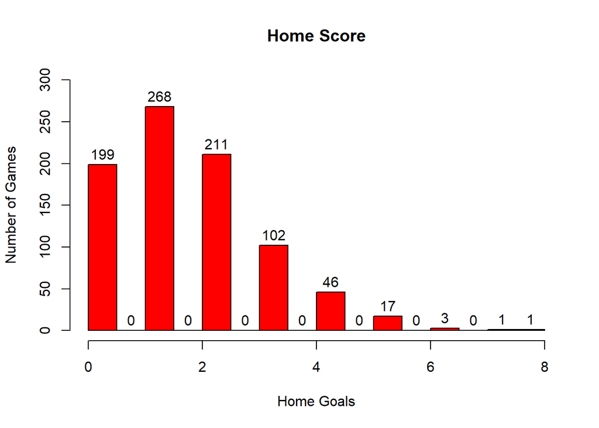

```r
hist(data$FTHG, freq=TRUE, labels=TRUE,xlab="Home Goals", ylab = "Number of Games", main = "Home Score", col = "red",right=FALSE, breaks = 20, ylim=c(0,300))
```

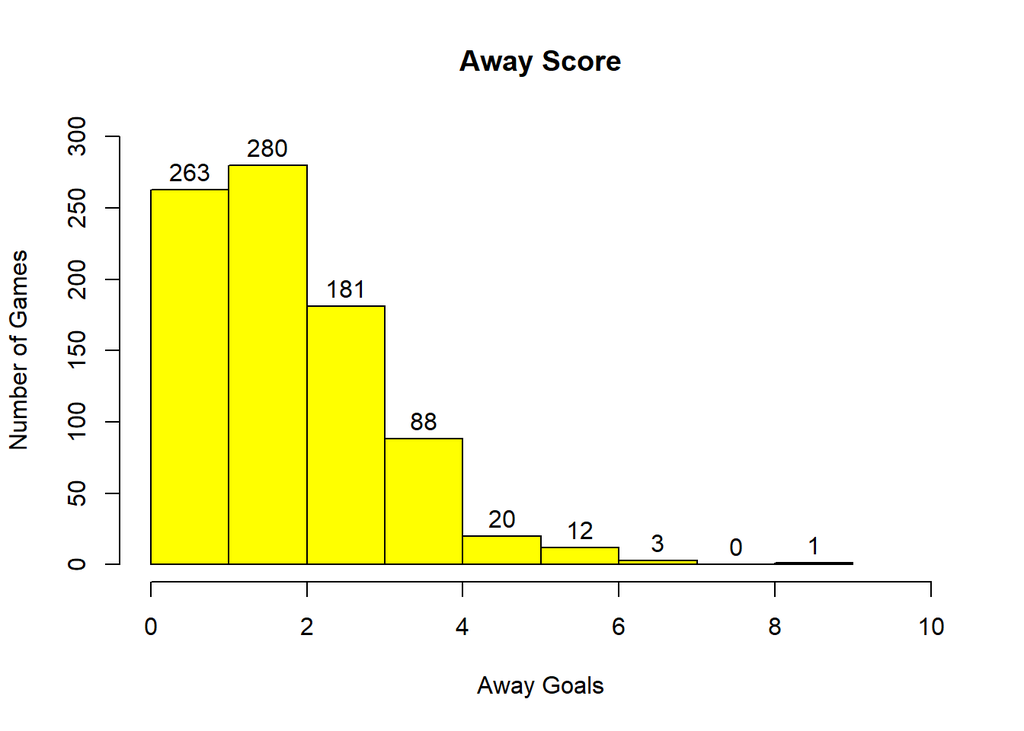

```r
hist(data$FTAG, freq=TRUE, labels=TRUE,xlab="Away Goals", ylab = "Number of Games", main = "Away Score", col = "yellow",right=FALSE, breaks = 10, ylim=c(0,300), xlim=c(0,10))
```

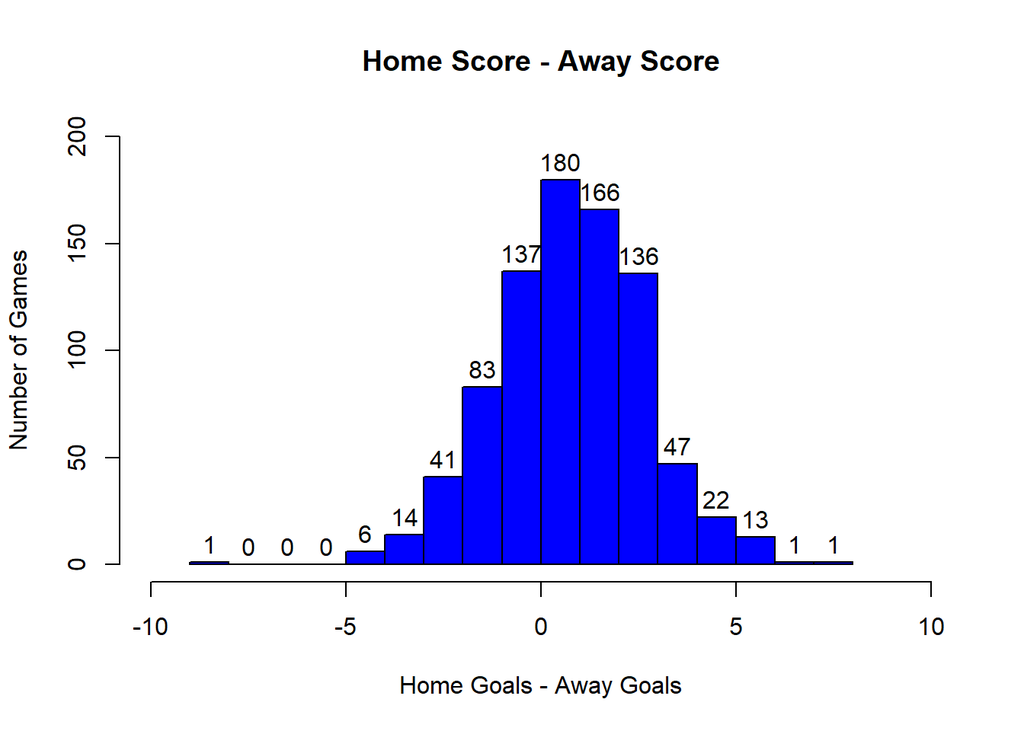

```r
hist(data$FTHG-data$FTAG, freq=TRUE, labels=TRUE,xlab="Home Goals - Away Goals", ylab = "Number of Games", main = "Home Score - Away Score", col = "blue",right=FALSE, breaks = 20, ylim=c(0,200), xlim=c(-10,10))
```

## Task 1 - Question 2

Firstly, we plot the histogram of Home Goals and compare its distribution with Poisson distribution. As the mean of the Poisson distribution, we take the sample mean. Secondly, we do the same staff for the Away Goals.

```r
h_mean = mean(data$FTHG)

h_mean
```

```
## [1] 1.53066
```

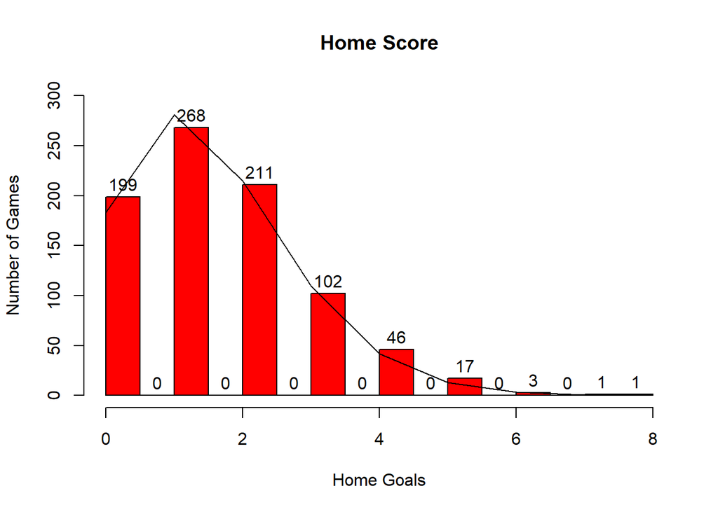

```r
a=dpois(0,h_mean)
b=dpois(1,h_mean)
c=dpois(2,h_mean)
d=dpois(3,h_mean)
e=dpois(4,h_mean)
f=dpois(5,h_mean)
g=dpois(6,h_mean)
h=dpois(7,h_mean)
j=dpois(8,h_mean)

exp_obs_h=c(a,b,c,d,e,f,g,h,j)*length(data$FTHG)



hist(data$FTHG, freq=TRUE, labels=TRUE,xlab="Home Goals", ylab = "Number of Games", main = "Home Score", col = "red",right=FALSE, breaks = 20, ylim=c(0,300))
lines(0:8,exp_obs_h)
```

This graph shows that Home Goals data distribution looks like *Poisson distribution* with mean $\lambda=1.531$.

```r
a_mean = mean(data$FTAG)

a_mean
```

```
## [1] 1.26533
```

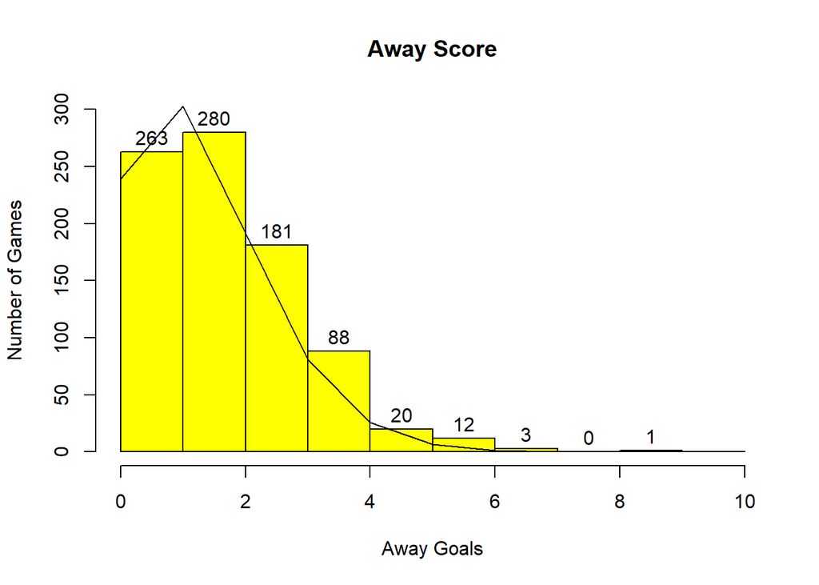

```r
l=dpois(0,a_mean)
m=dpois(1,a_mean)
n=dpois(2,a_mean)
o=dpois(3,a_mean)
p=dpois(4,a_mean)
r=dpois(5,a_mean)
s=dpois(6,a_mean)
t=dpois(7,a_mean)
u=dpois(8,a_mean)
v=dpois(9,a_mean)
y=dpois(10,a_mean)

exp_obs_a=c(l,m,n,o,p,r,s,t,u,v,y)*length(data$FTAG)



hist(data$FTAG, freq=TRUE, labels=TRUE,xlab="Away Goals", ylab = "Number of Games", main = "Away Score", col = "yellow",right=FALSE, breaks = 10, ylim=c(0,300), xlim=c(0,10))
lines(0:10,exp_obs_a)
```

This graph shows that Away Goals data distribution looks like *Poisson distribution* with mean $\lambda=1.265$.

## Task 2 - Question 1

We selected 4 bookmakers: *Bet365, BetAndWin,Pinnacle and William Hill*.

```r
fprobs = 1/data[,c("B365H","B365D","B365A","BWH","BWD","BWA","PSH","PSD","PSA","WHH","WHD","WHA")]

names(fprobs) <- c("B365H_prob","B365D_prob","B365A_prob","BWH_prob","BWD_prob","BWA_prob","PSH_prob","PSD_prob","PSA_prob","WHH_prob","WHD_prob","WHA_prob")

head(fprobs,10)
```

```
##    B365H_prob B365D_prob B365A_prob  BWH_prob  BWD_prob  BWA_prob
## 1   0.1666667  0.2309469  0.6535948 0.1818182 0.2352941 0.6369427
## 2   0.3225806  0.3076923  0.4219409 0.3333333 0.3125000 0.4081633
## 3   0.7812500  0.1666667  0.1052632 0.7936508 0.1600000 0.0952381
## 4   0.4651163  0.2941176  0.2941176 0.4651163 0.2941176 0.2941176
## 5   0.2631579  0.2777778  0.5128205 0.2702703 0.2777778 0.5000000
## 6   0.5464481  0.2777778  0.2309469 0.5405405 0.2777778 0.2309469
## 7   0.2000000  0.2309469  0.6211180 0.2000000 0.2439024 0.6060606
## 8   0.3076923  0.3225806  0.4219409 0.2941176 0.3225806 0.4347826
## 9   0.6666667  0.2380952  0.1538462 0.6451613 0.2380952 0.1666667
## 10  0.6211180  0.2564103  0.1739130 0.6172840 0.2500000 0.1818182
##     PSH_prob  PSD_prob  PSA_prob  WHH_prob  WHD_prob  WHA_prob
## 1  0.1623377 0.2217295 0.6410256 0.1538462 0.2380952 0.6535948
## 2  0.3012048 0.3039514 0.4166667 0.3125000 0.3125000 0.4255319
## 3  0.7633588 0.1600000 0.1008065 0.7874016 0.1666667 0.1000000
## 4  0.4587156 0.2770083 0.2857143 0.4651163 0.2857143 0.2941176
## 5  0.2500000 0.2785515 0.5000000 0.2631579 0.2777778 0.5128205
## 6  0.5154639 0.2801120 0.2325581 0.5319149 0.2857143 0.2309469
## 7  0.1865672 0.2304147 0.6060606 0.1904762 0.2500000 0.6060606
## 8  0.2932551 0.3300330 0.4065041 0.3030303 0.3225806 0.4201681
## 9  0.6451613 0.2309469 0.1547988 0.6578947 0.2380952 0.1538462
## 10 0.6060606 0.2469136 0.1782531 0.6134969 0.2564103 0.1818182
```

```r
data_with_prob <- cbind(data,fprobs)
```

Calculated probabalities of **home win, draw and away win** for each bookmaker.

## Task 2 - Question 2

Normalized probabilities are calculated for each bookmaker separately.

```r
normprobs=data.frame()

for(i in 1:length(data_with_prob[,1])){
  normprobs[i,1] <- fprobs[i,"B365H_prob"]/sum(fprobs[i,"B365H_prob"],fprobs[i,"B365D_prob"],fprobs[i,"B365A_prob"])
  normprobs[i,2] <- fprobs[i,"B365D_prob"]/sum(fprobs[i,"B365H_prob"],fprobs[i,"B365D_prob"],fprobs[i,"B365A_prob"])
  normprobs[i,3] <- fprobs[i,"B365A_prob"]/sum(fprobs[i,"B365H_prob"],fprobs[i,"B365D_prob"],fprobs[i,"B365A_prob"])
  normprobs[i,4] <- fprobs[i,"BWH_prob"]/sum(fprobs[i,"BWH_prob"],fprobs[i,"BWD_prob"],fprobs[i,"BWA_prob"])
  normprobs[i,5] <- fprobs[i,"BWD_prob"]/sum(fprobs[i,"BWH_prob"],fprobs[i,"BWD_prob"],fprobs[i,"BWA_prob"])
  normprobs[i,6] <- fprobs[i,"BWA_prob"]/sum(fprobs[i,"BWH_prob"],fprobs[i,"BWD_prob"],fprobs[i,"BWA_prob"])
  normprobs[i,7] <- fprobs[i,"PSH_prob"]/sum(fprobs[i,"PSH_prob"],fprobs[i,"PSD_prob"],fprobs[i,"PSA_prob"])
  normprobs[i,8] <- fprobs[i,"PSD_prob"]/sum(fprobs[i,"PSH_prob"],fprobs[i,"PSD_prob"],fprobs[i,"PSA_prob"])
  normprobs[i,9] <- fprobs[i,"PSA_prob"]/sum(fprobs[i,"PSH_prob"],fprobs[i,"PSD_prob"],fprobs[i,"PSA_prob"])
  normprobs[i,10] <- fprobs[i,"WHH_prob"]/sum(fprobs[i,"WHH_prob"],fprobs[i,"WHD_prob"],fprobs[i,"WHA_prob"])
  normprobs[i,11] <- fprobs[i,"WHD_prob"]/sum(fprobs[i,"WHH_prob"],fprobs[i,"WHD_prob"],fprobs[i,"WHA_prob"])
  normprobs[i,12] <- fprobs[i,"WHA_prob"]/sum(fprobs[i,"WHH_prob"],fprobs[i,"WHD_prob"],fprobs[i,"WHA_prob"])
}
names(normprobs) = c("norm_B365H_probs","norm_B365D_probs","norm_B365A_probs","norm_BWH_probs","norm_BWD_probs","norm_BWA_probs","norm_PSH_probs","norm_PSD_probs","norm_PSA_probs","norm_WHH_probs","norm_WHD_probs","norm_WHA_probs")

head(normprobs,10)
```

```
##    norm_B365H_probs norm_B365D_probs norm_B365A_probs norm_BWH_probs
## 1         0.1585477        0.2196966       0.62175571      0.1724940
## 2         0.3065733        0.2924237       0.40100301      0.3162566
## 3         0.7418011        0.1582509       0.09994794      0.7566586
## 4         0.4415584        0.2792208       0.27922078      0.4415584
## 5         0.2497332        0.2636073       0.48665955      0.2578797
## 6         0.5178755        0.2632534       0.21887116      0.5151610
## 7         0.1901023        0.2195177       0.59037994      0.1904829
## 8         0.2924237        0.3065733       0.40100301      0.2797175
## 9         0.6297578        0.2249135       0.14532872      0.6144843
## 10        0.5907301        0.2438655       0.16540442      0.5883926
##    norm_BWD_probs norm_BWA_probs norm_PSH_probs norm_PSD_probs
## 1       0.2232276     0.60427842      0.1583639      0.2163019
## 2       0.2964905     0.38725292      0.2947721      0.2974599
## 3       0.1525424     0.09079903      0.7453473      0.1562248
```

[output cut: 18 more lines]

```r
data_with_prob <- cbind(data_with_prob,normprobs)
```

## Task 2 - Question 3

Firstly, we calculated *P(home win)-P(away win)*.

```r
data_with_prob["B365Diff"]=data_with_prob["norm_B365H_probs"]-data_with_prob["norm_B365A_probs"]
data_with_prob["BWDiff"]=data_with_prob["norm_BWH_probs"]-data_with_prob["norm_BWA_probs"]
data_with_prob["PSDiff"]=data_with_prob["norm_PSH_probs"]-data_with_prob["norm_PSA_probs"]
data_with_prob["WHDiff"]=data_with_prob["norm_WHH_probs"]-data_with_prob["norm_WHA_probs"]
```

We determined the bins as follows:

```r
bins= c(-1,-0.8,-0.6,-0.4,-0.2,0,0.2,0.4,0.6,0.8,1)
```

As a first bookmaker, we examined Bet365.

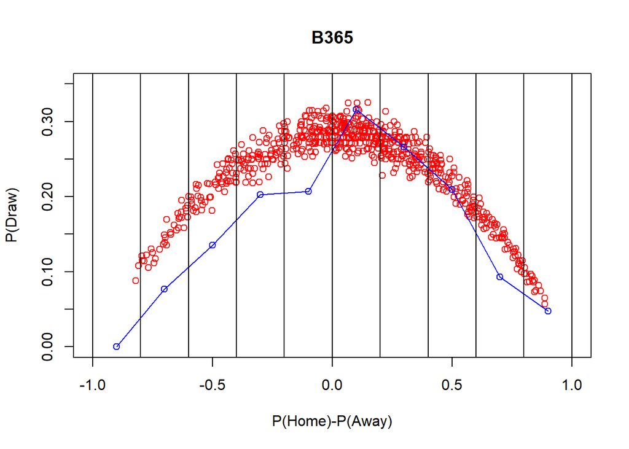

```r
#B365

counter=rep(0,10)
counter1=rep(0,10)
for(j in 1:10){
  counter[j]=length(subset(data_with_prob,B365Diff>bins[j] & B365Diff<bins[j+1])[,1])
  counter1[j]=length(subset(data_with_prob,FTR=="D" & B365Diff>bins[j] & B365Diff<bins[j+1])[,1])
}

probability_of_draw=rep(0,10)
new_bins=rep(0,10)
for (k in 1:10){
  probability_of_draw[k]=counter1[k]/counter[k]
  new_bins[k] = (bins[k]+bins[k+1])/2
}

plot(data_with_prob$B365Diff,data_with_prob$norm_B365D_probs, main="B365",col="red",ylim = c(0,0.35),xlim=c(-1,1),ylab="P(Draw)",xlab="P(Home)-P(Away)")
lines(new_bins,probability_of_draw,col="blue",type="o")
abline(v=bins)
```

Second bookmaker is BetAndWin.

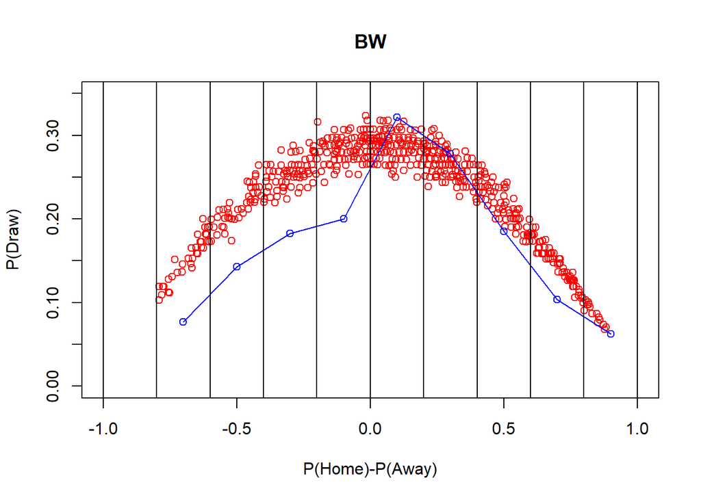

```r
counter=rep(0,10)
counter1=rep(0,10)
for(j in 1:10){
  counter[j]=length(subset(data_with_prob,BWDiff>bins[j] & BWDiff<bins[j+1])[,1])
  counter1[j]=length(subset(data_with_prob,FTR=="D" & BWDiff>bins[j] & BWDiff<bins[j+1])[,1])
}

probability_of_draw=rep(0,10)
new_bins=rep(0,10)
for (k in 1:10){
  probability_of_draw[k]=counter1[k]/counter[k]
  new_bins[k] = (bins[k]+bins[k+1])/2
}

plot(data_with_prob$BWDiff,data_with_prob$norm_BWD_probs, main="BW",col="red",ylim = c(0,0.35),xlim=c(-1,1),ylab="P(Draw)",xlab="P(Home)-P(Away)")
lines(new_bins,probability_of_draw,col="blue",type="o")
abline(v=bins)
```

Third bookmaker is Pinnacle.

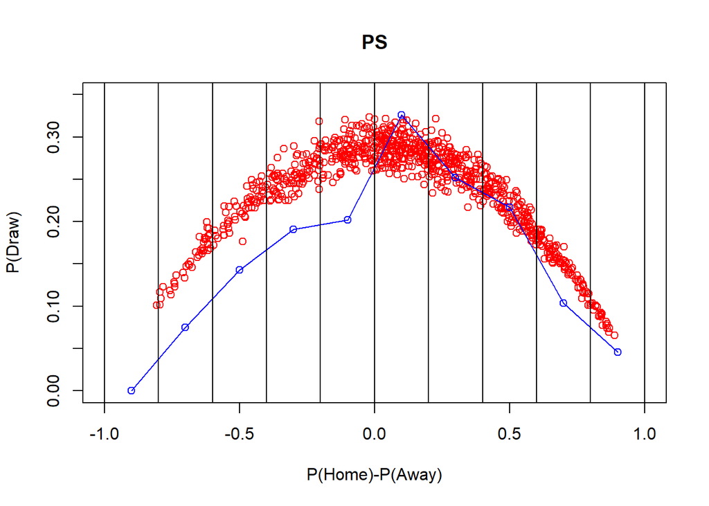

```r
counter=rep(0,10)
counter1=rep(0,10)
for(j in 1:10){
  counter[j]=length(subset(data_with_prob,PSDiff>bins[j] & PSDiff<bins[j+1])[,1])
  counter1[j]=length(subset(data_with_prob,FTR=="D" & PSDiff>bins[j] & PSDiff<bins[j+1])[,1])
}

probability_of_draw=rep(0,10)
new_bins=rep(0,10)
for (k in 1:10){
  probability_of_draw[k]=counter1[k]/counter[k]
  new_bins[k] = (bins[k]+bins[k+1])/2
}

plot(data_with_prob$PSDiff,data_with_prob$norm_PSD_probs, main="PS",col="red",ylim = c(0,0.35),xlim=c(-1,1),ylab="P(Draw)",xlab="P(Home)-P(Away)")
lines(new_bins,probability_of_draw,col="blue",type="o")
abline(v=bins)
```

Fourth bookmaker is William Hill.

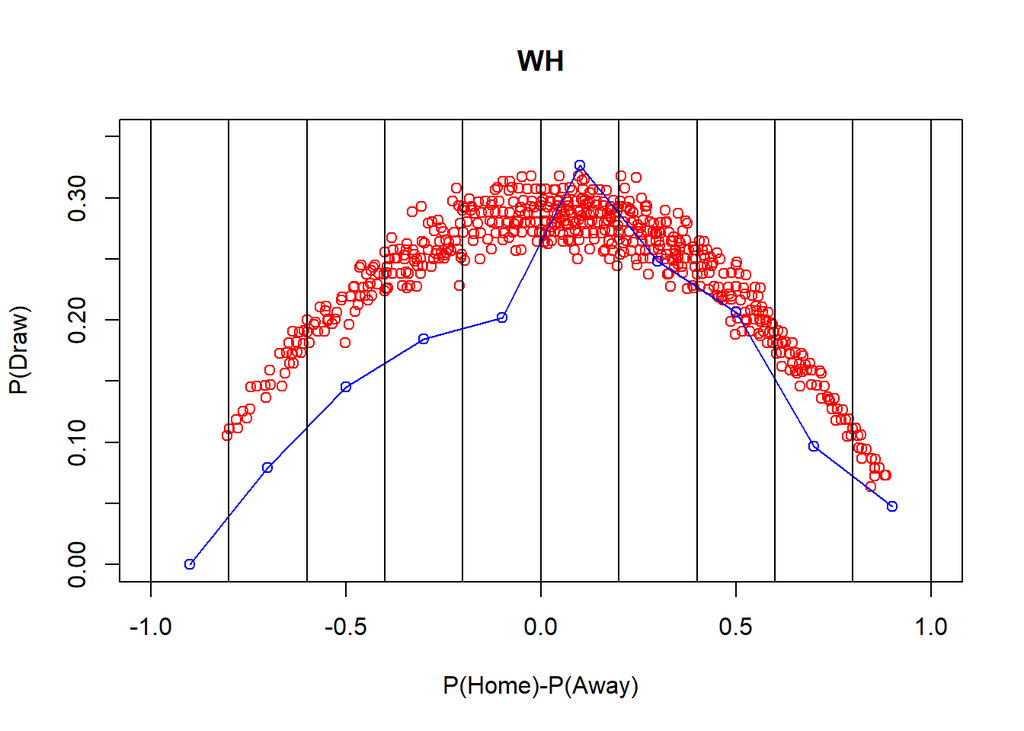

```r
counter=rep(0,10)
counter1=rep(0,10)
for(j in 1:10){
  counter[j]=length(subset(data_with_prob,WHDiff>bins[j] & WHDiff<bins[j+1])[,1])
  counter1[j]=length(subset(data_with_prob,FTR=="D" & WHDiff>bins[j] & WHDiff<bins[j+1])[,1])
}

probability_of_draw=rep(0,10)
new_bins=rep(0,10)
for (k in 1:10){
  probability_of_draw[k]=counter1[k]/counter[k]
  new_bins[k] = (bins[k]+bins[k+1])/2
}

plot(data_with_prob$WHDiff,data_with_prob$norm_WHD_probs, main="WH",col="red",ylim = c(0,0.35),xlim=c(-1,1),ylab="P(Draw)",xlab="P(Home)-P(Away)")
lines(new_bins,probability_of_draw,col="blue",type="o")
abline(v=bins)
```

## Task 2 - Question 4

It can be seen from the graphs above, actual probabilities for most of the games in the interval *0 < P(home win)- P(away win) < 0.4*, are higher than odd probablities given by bookmakers. Therefore, we can say that there is a positive bias in these odds.

## Task 3 - Question

Firstly, we need to discard the matches with red cards.

```r
data_with_prob["total_red"]=data_with_prob["HR"]+data_with_prob["AR"]
without_redcard=subset(data_with_prob,total_red==0)
```

Now, we just changed our main data set to examine the games without red card.We will use the same bookmakers to compare results with general case.

For Bet365:

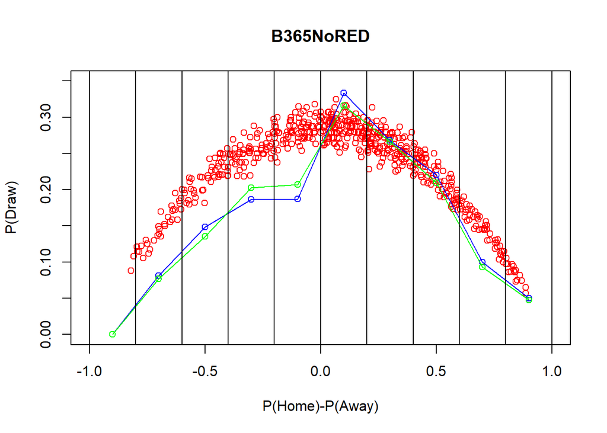

```r
counter=rep(0,10)
counter1=rep(0,10)
for(j in 1:10){
  counter[j]=length(subset(data_with_prob,B365Diff>bins[j] & B365Diff<bins[j+1])[,1])
  counter1[j]=length(subset(data_with_prob,FTR=="D" & B365Diff>bins[j] & B365Diff<bins[j+1])[,1])
}



counter_nored=rep(0,10)
counter1_nored=rep(0,10)
for(j in 1:10){
counter_nored[j]=length(subset(without_redcard,B365Diff>bins[j] & B365Diff<bins[j+1])[,1])
counter1_nored[j]=length(subset(without_redcard,FTR=="D" & B365Diff>bins[j] & B365Diff<bins[j+1])[,1])
}


probability_of_draw=rep(0,10)
new_bins=rep(0,10)
for (k in 1:10){
  probability_of_draw[k]=counter1[k]/counter[k]
  new_bins[k] = (bins[k]+bins[k+1])/2
}

probability_of_draw_noredcard=rep(0,10)

for (k in 1:10){
  probability_of_draw_noredcard[k]=counter1_nored[k]/counter_nored[k]

}

plot(without_redcard$B365Diff,without_redcard$norm_B365D_probs, main="B365NoRED",col="red",ylim = c(0,0.35),xlim=c(-1,1),ylab="P(Draw)",xlab="P(Home)-P(Away)")
lines(new_bins,probability_of_draw_noredcard,col="blue",type="o")
lines(new_bins,probability_of_draw,col="green",type="o")
abline(v=bins)
```

For BetAndWin:

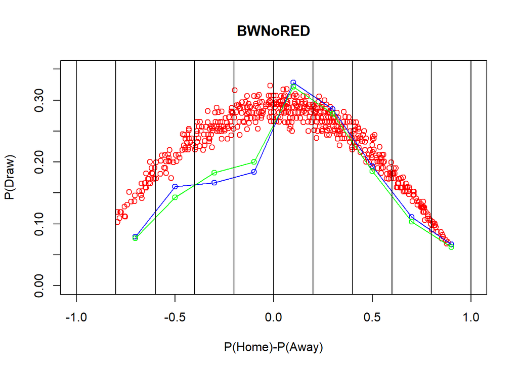

```r
counter=rep(0,10)
counter1=rep(0,10)
for(j in 1:10){
  counter[j]=length(subset(data_with_prob,BWDiff>bins[j] & BWDiff<bins[j+1])[,1])
  counter1[j]=length(subset(data_with_prob,FTR=="D" & BWDiff>bins[j] & BWDiff<bins[j+1])[,1])
}



counter_nored=rep(0,10)
counter1_nored=rep(0,10)
for(j in 1:10){
  counter_nored[j]=length(subset(without_redcard,BWDiff>bins[j] & BWDiff<bins[j+1])[,1])
  counter1_nored[j]=length(subset(without_redcard,FTR=="D" & BWDiff>bins[j] & BWDiff<bins[j+1])[,1])
}


probability_of_draw=rep(0,10)
new_bins=rep(0,10)
for (k in 1:10){
  probability_of_draw[k]=counter1[k]/counter[k]
  new_bins[k] = (bins[k]+bins[k+1])/2
}

probability_of_draw_noredcard=rep(0,10)

for (k in 1:10){
  probability_of_draw_noredcard[k]=counter1_nored[k]/counter_nored[k]

}

plot(without_redcard$BWDiff,without_redcard$norm_BWD_probs, main="BWNoRED",col="red",ylim = c(0,0.35),xlim=c(-1,1),ylab="P(Draw)",xlab="P(Home)-P(Away)")
lines(new_bins,probability_of_draw_noredcard,col="blue",type="o")
lines(new_bins,probability_of_draw,col="green",type="o")
abline(v=bins)
```

For Pinnacle:

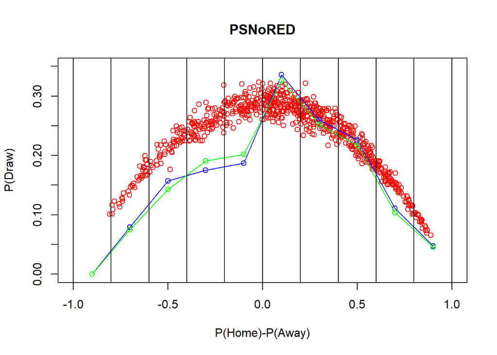

```r
counter=rep(0,10)
counter1=rep(0,10)
for(j in 1:10){
  counter[j]=length(subset(data_with_prob,PSDiff>bins[j] & PSDiff<bins[j+1])[,1])
  counter1[j]=length(subset(data_with_prob,FTR=="D" & PSDiff>bins[j] & PSDiff<bins[j+1])[,1])
}



counter_nored=rep(0,10)
counter1_nored=rep(0,10)
for(j in 1:10){
  counter_nored[j]=length(subset(without_redcard,PSDiff>bins[j] & PSDiff<bins[j+1])[,1])
  counter1_nored[j]=length(subset(without_redcard,FTR=="D" & PSDiff>bins[j] & PSDiff<bins[j+1])[,1])
}


probability_of_draw=rep(0,10)
new_bins=rep(0,10)
for (k in 1:10){
  probability_of_draw[k]=counter1[k]/counter[k]
  new_bins[k] = (bins[k]+bins[k+1])/2
}

probability_of_draw_noredcard=rep(0,10)

for (k in 1:10){
  probability_of_draw_noredcard[k]=counter1_nored[k]/counter_nored[k]

}

plot(without_redcard$PSDiff,without_redcard$norm_PSD_probs, main="PSNoRED",col="red",ylim = c(0,0.35),xlim=c(-1,1),ylab="P(Draw)",xlab="P(Home)-P(Away)")
lines(new_bins,probability_of_draw_noredcard,col="blue",type="o")
lines(new_bins,probability_of_draw,col="green",type="o")
abline(v=bins)
```

For William Hill:

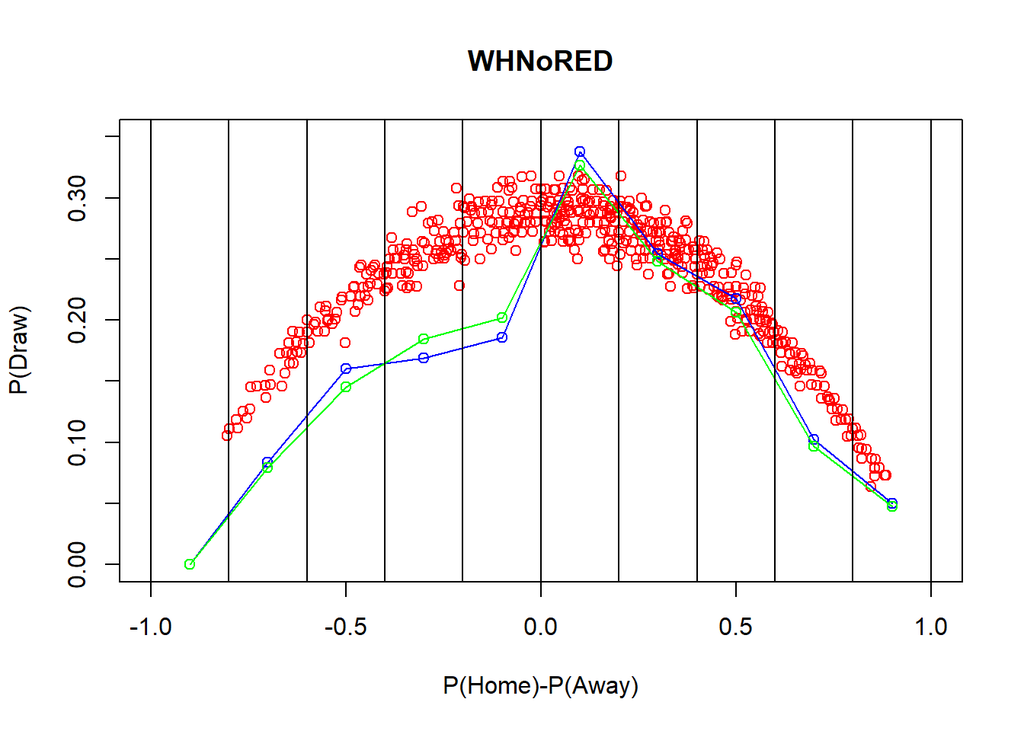

```r
counter=rep(0,10)
counter1=rep(0,10)
for(j in 1:10){
  counter[j]=length(subset(data_with_prob,WHDiff>bins[j] & WHDiff<bins[j+1])[,1])
  counter1[j]=length(subset(data_with_prob,FTR=="D" & WHDiff>bins[j] & WHDiff<bins[j+1])[,1])
}



counter_nored=rep(0,10)
counter1_nored=rep(0,10)
for(j in 1:10){
  counter_nored[j]=length(subset(without_redcard,WHDiff>bins[j] & WHDiff<bins[j+1])[,1])
  counter1_nored[j]=length(subset(without_redcard,FTR=="D" & WHDiff>bins[j] & WHDiff<bins[j+1])[,1])
}


probability_of_draw=rep(0,10)
new_bins=rep(0,10)
for (k in 1:10){
  probability_of_draw[k]=counter1[k]/counter[k]
  new_bins[k] = (bins[k]+bins[k+1])/2
}

probability_of_draw_noredcard=rep(0,10)

for (k in 1:10){
  probability_of_draw_noredcard[k]=counter1_nored[k]/counter_nored[k]

}

plot(without_redcard$WHDiff,without_redcard$norm_WHD_probs, main="WHNoRED",col="red",ylim = c(0,0.35),xlim=c(-1,1),ylab="P(Draw)",xlab="P(Home)-P(Away)")
lines(new_bins,probability_of_draw_noredcard,col="blue",type="o")
lines(new_bins,probability_of_draw,col="green",type="o")
abline(v=bins)
```

After removing the games with red card, actual probabilities are slightly shifted above ( except the interal -0.4 < P(home)-P(away) < 0).